# Linear Regression

Nguyen Minh Thanh

December 21, 2016

# 1 Định nghĩa và giả thiết về Linear Regression

## 1.1 Định nghĩa

Hàm số thể hiện sự tương quan giữa 2 biến: X và Y. Trong đó Y là biến phụ thuộc, X là biến độc lập sao cho khoảng cách giữa các điểm của biến trên đồ thị đến hàm số là nhỏ nhất. Khoảng cách đó được gọi là sai số (Residual)

Linear Regression có dạng:

$$Y = aXi + b +ε$$

Trong đó

Xi: biến độc lập

Yi: biến phụ thuộc

ε: sai số

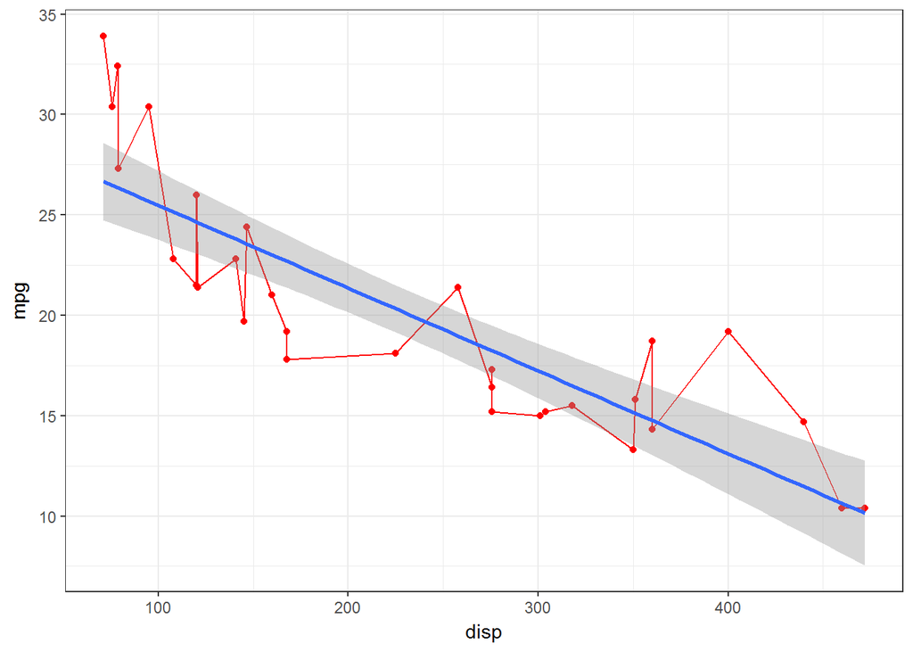

```r
data %>% ggplot(aes(x = disp, y = mpg)) +
  geom_line(col="red") +
  geom_point(col= "red") +
  geom_smooth(method = lm)  +
  theme_bw()
```

## 1.2 Các giả thiết của Linear Regression

- Biến số độc lập có phân phối chuẩn (Normal distribution)
- Các biến độc lập không có mối quan hệ tuyến tính (Independence)
- Các biến độc lập phải có mối quan hệ tuyến tính với biến phụ thuộc (Linearity)
- Phương sai biến phụ thuộc có mức thay đổi bằng nhau khi giá trị của biến độc lập thay đổi (Homoskedasticity)

# 2 Các bước lập Linear Regression

## 2.1 Mô tả dữ liệu

### 2.1.1 Xem các chỉ số cơ bản của dữ liệu

```r
data %>% summary
```

```
##       mpg             cyl             disp             hp
##  Min.   :10.40   Min.   :4.000   Min.   : 71.1   Min.   : 52.0
##  1st Qu.:15.43   1st Qu.:4.000   1st Qu.:120.8   1st Qu.: 96.5
##  Median :19.20   Median :6.000   Median :196.3   Median :123.0
##  Mean   :20.09   Mean   :6.188   Mean   :230.7   Mean   :146.7
##  3rd Qu.:22.80   3rd Qu.:8.000   3rd Qu.:326.0   3rd Qu.:180.0
##  Max.   :33.90   Max.   :8.000   Max.   :472.0   Max.   :335.0
##       drat             wt             qsec             vs
##  Min.   :2.760   Min.   :1.513   Min.   :14.50   Min.   :0.0000
##  1st Qu.:3.080   1st Qu.:2.581   1st Qu.:16.89   1st Qu.:0.0000
##  Median :3.695   Median :3.325   Median :17.71   Median :0.0000
##  Mean   :3.597   Mean   :3.217   Mean   :17.85   Mean   :0.4375
##  3rd Qu.:3.920   3rd Qu.:3.610   3rd Qu.:18.90   3rd Qu.:1.0000
##  Max.   :4.930   Max.   :5.424   Max.   :22.90   Max.   :1.0000
##        am              gear            carb
##  Min.   :0.0000   Min.   :3.000   Min.   :1.000
##  1st Qu.:0.0000   1st Qu.:3.000   1st Qu.:2.000
##  Median :0.0000   Median :4.000   Median :2.000
##  Mean   :0.4062   Mean   :3.688   Mean   :2.812
##  3rd Qu.:1.0000   3rd Qu.:4.000   3rd Qu.:4.000
##  Max.   :1.0000   Max.   :5.000   Max.   :8.000
```

### 2.1.2 Hệ số tương quan giữa các biến:

Linear Regression sẽ là hàm số tốt khi bao gồm các biến độc lập có hệ số tương quan với biến phụ thuộc trong khoảng từ 0.3 đến 0.8

```r
cor(mtcars)
```

```
##             mpg        cyl       disp         hp        drat         wt
## mpg   1.0000000 -0.8521620 -0.8475514 -0.7761684  0.68117191 -0.8676594
## cyl  -0.8521620  1.0000000  0.9020329  0.8324475 -0.69993811  0.7824958
## disp -0.8475514  0.9020329  1.0000000  0.7909486 -0.71021393  0.8879799
## hp   -0.7761684  0.8324475  0.7909486  1.0000000 -0.44875912  0.6587479
## drat  0.6811719 -0.6999381 -0.7102139 -0.4487591  1.00000000 -0.7124406
## wt   -0.8676594  0.7824958  0.8879799  0.6587479 -0.71244065  1.0000000
## qsec  0.4186840 -0.5912421 -0.4336979 -0.7082234  0.09120476 -0.1747159
## vs    0.6640389 -0.8108118 -0.7104159 -0.7230967  0.44027846 -0.5549157
## am    0.5998324 -0.5226070 -0.5912270 -0.2432043  0.71271113 -0.6924953
## gear  0.4802848 -0.4926866 -0.5555692 -0.1257043  0.69961013 -0.5832870
## carb -0.5509251  0.5269883  0.3949769  0.7498125 -0.09078980  0.4276059
##             qsec         vs          am       gear        carb
## mpg   0.41868403  0.6640389  0.59983243  0.4802848 -0.55092507
## cyl  -0.59124207 -0.8108118 -0.52260705 -0.4926866  0.52698829
## disp -0.43369788 -0.7104159 -0.59122704 -0.5555692  0.39497686
## hp   -0.70822339 -0.7230967 -0.24320426 -0.1257043  0.74981247
## drat  0.09120476  0.4402785  0.71271113  0.6996101 -0.09078980
## wt   -0.17471588 -0.5549157 -0.69249526 -0.5832870  0.42760594
## qsec  1.00000000  0.7445354 -0.22986086 -0.2126822 -0.65624923
## vs    0.74453544  1.0000000  0.16834512  0.2060233 -0.56960714
## am   -0.22986086  0.1683451  1.00000000  0.7940588  0.05753435
## gear -0.21268223  0.2060233  0.79405876  1.0000000  0.27407284
## carb -0.65624923 -0.5696071  0.05753435  0.2740728  1.00000000
```

Các biến thỏa mãn:

```r
cor.data <- cor(mtcars) %>% as.data.frame()
melt.data <- melt(cor.data[1,], id.vars = c("mpg"))
melt.data[,2:3] %>% filter(value >= 0.3 & value <= 0.8| value >= -0.8 & value <= -0.3)
```

```
##   variable      value
## 1       hp -0.7761684
## 2     drat  0.6811719
## 3     qsec  0.4186840
## 4       vs  0.6640389
## 5       am  0.5998324
## 6     gear  0.4802848
## 7     carb -0.5509251
```

Dựa trên tập data mtcars ta có thể thấy các biến: hp, drat, qsec, vs … có thể đưa vào sử dụng trong Linear Regression

### 2.1.3 Phân phối của biến

Theo giả thiết, các biến của Linear Regression phải có phân phối chuẩn (dạng hình chuông)

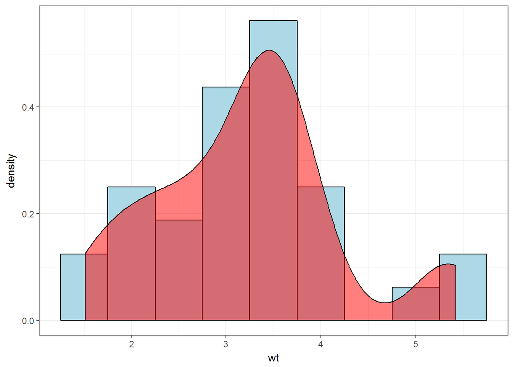

```r
mtcars %>%
  ggplot(aes(x=wt)) +
    geom_histogram(aes(y=..density..),
                   binwidth = 0.5,
                   colour="black", fill="lightblue") +
    geom_density(alpha=.5, fill="red")  +
    theme_bw()
```

Test phân phối của biến:

- Ho: Biến số phân phối chuẩn
- H1: Biến số không có phân phối chuẩn

```r
shapiro.test(data$wt)
```

```
##
##  Shapiro-Wilk normality test
##
## data:  data$wt
## W = 0.94326, p-value = 0.09265
```

P-value > 0.05 do đó ta có thể chấp nhận Ho và từ chối H1

**Kết luận:** Biến wt có phân phối chuẩn

# 3 Linear Regression

```r
model1 <- lm(mpg ~ drat + wt + hp, data = mtcars)
model1 %>% summary
```

```
##
## Call:
## lm(formula = mpg ~ drat + wt + hp, data = mtcars)
##
## Residuals:
##     Min      1Q  Median      3Q     Max
## -3.3598 -1.8374 -0.5099  0.9681  5.7078
##
## Coefficients:
##              Estimate Std. Error t value Pr(>|t|)
## (Intercept) 29.394934   6.156303   4.775 5.13e-05 ***
## drat         1.615049   1.226983   1.316 0.198755
## wt          -3.227954   0.796398  -4.053 0.000364 ***
## hp          -0.032230   0.008925  -3.611 0.001178 **
## ---
## Signif. codes:  0 '***' 0.001 '**' 0.01 '*' 0.05 '.' 0.1 ' ' 1
##
## Residual standard error: 2.561 on 28 degrees of freedom
## Multiple R-squared:  0.8369, Adjusted R-squared:  0.8194
## F-statistic: 47.88 on 3 and 28 DF,  p-value: 3.768e-11
```

## 3.1 Cách chọn tự động chọn mô hình tốt nhất

- Forward: mô hình không có sự tham gia của biến nào sẽ được build rồi thêm từng biến với mô hình sao cho sau khi thêm biến thì AIC là nhỏ nhất cho đến khi chọn được mô hình có AIC là bé nhất để chọn ra mô hình tốt nhất

```r
null <- lm(mpg ~ 1, data = data)
full <- lm(mpg ~ . , data = data)
step(null,scope = list(lower=null,upper = full),direction = "forward")
```

```
## Start:  AIC=115.94
## mpg ~ 1
##
##        Df Sum of Sq     RSS     AIC
## + wt    1    847.73  278.32  73.217
## + cyl   1    817.71  308.33  76.494
## + disp  1    808.89  317.16  77.397
## + hp    1    678.37  447.67  88.427
## + drat  1    522.48  603.57  97.988
## + vs    1    496.53  629.52  99.335
## + am    1    405.15  720.90 103.672
## + carb  1    341.78  784.27 106.369
## + gear  1    259.75  866.30 109.552
## + qsec  1    197.39  928.66 111.776
## <none>              1126.05 115.943
##
## Step:  AIC=73.22
## mpg ~ wt
##
##        Df Sum of Sq    RSS    AIC
## + cyl   1    87.150 191.17 63.198
## + hp    1    83.274 195.05 63.840
## + qsec  1    82.858 195.46 63.908
## + vs    1    54.228 224.09 68.283
## + carb  1    44.602 233.72 69.628
## + disp  1    31.639 246.68 71.356
## <none>              278.32 73.217
## + drat  1     9.081 269.24 74.156
## + gear  1     1.137 277.19 75.086
## + am    1     0.002 278.32 75.217
##
## Step:  AIC=63.2
## mpg ~ wt + cyl
##
##        Df Sum of Sq    RSS    AIC
## + hp    1   14.5514 176.62 62.665
## + carb  1   13.7724 177.40 62.805
## <none>              191.17 63.198
## + qsec  1   10.5674 180.60 63.378
## + gear  1    3.0281 188.14 64.687
## + disp  1    2.6796 188.49 64.746
## + vs    1    0.7059 190.47 65.080
## + am    1    0.1249 191.05 65.177
## + drat  1    0.0010 191.17 65.198
##
## Step:  AIC=62.66
## mpg ~ wt + cyl + hp
##
##        Df Sum of Sq    RSS    AIC
## <none>              176.62 62.665
## + am    1    6.6228 170.00 63.442
## + disp  1    6.1762 170.44 63.526
## + carb  1    2.5187 174.10 64.205
## + drat  1    2.2453 174.38 64.255
## + qsec  1    1.4010 175.22 64.410
## + gear  1    0.8558 175.76 64.509
## + vs    1    0.0599 176.56 64.654
```

```
##
## Call:
## lm(formula = mpg ~ wt + cyl + hp, data = data)
##
## Coefficients:
## (Intercept)           wt          cyl           hp
##    38.75179     -3.16697     -0.94162     -0.01804
```

```r
regsubsets(mpg ~ ., nvmax =  10 , method = "forward", data = data) %>%
  summary
```

```
## Subset selection object
## Call: regsubsets.formula(mpg ~ ., nvmax = 10, method = "forward", data = data)
## 10 Variables  (and intercept)
##      Forced in Forced out
## cyl      FALSE      FALSE
## disp     FALSE      FALSE
## hp       FALSE      FALSE
## drat     FALSE      FALSE
## wt       FALSE      FALSE
## qsec     FALSE      FALSE
## vs       FALSE      FALSE
## am       FALSE      FALSE
## gear     FALSE      FALSE
## carb     FALSE      FALSE
## 1 subsets of each size up to 10
## Selection Algorithm: forward
##           cyl disp hp  drat wt  qsec vs  am  gear carb
## 1  ( 1 )  " " " "  " " " "  "*" " "  " " " " " "  " "
## 2  ( 1 )  "*" " "  " " " "  "*" " "  " " " " " "  " "
## 3  ( 1 )  "*" " "  "*" " "  "*" " "  " " " " " "  " "
## 4  ( 1 )  "*" " "  "*" " "  "*" " "  " " "*" " "  " "
## 5  ( 1 )  "*" " "  "*" " "  "*" "*"  " " "*" " "  " "
## 6  ( 1 )  "*" "*"  "*" " "  "*" "*"  " " "*" " "  " "
## 7  ( 1 )  "*" "*"  "*" "*"  "*" "*"  " " "*" " "  " "
## 8  ( 1 )  "*" "*"  "*" "*"  "*" "*"  " " "*" "*"  " "
## 9  ( 1 )  "*" "*"  "*" "*"  "*" "*"  " " "*" "*"  "*"
## 10  ( 1 ) "*" "*"  "*" "*"  "*" "*"  "*" "*" "*"  "*"
```

- Backward: mô hình có sự tham gia của tất cả các biến sẽ được build rồi bỏ từng biến với mô hình sao cho sau khi bỏ biến thì AIC là nhỏ nhất cho đến khi chọn được mô hình có AIC là bé nhất để chọn ra mô hình tốt nhất

```r
step(full,data = data, direction = "backward" )
```

```
## Start:  AIC=70.9
## mpg ~ cyl + disp + hp + drat + wt + qsec + vs + am + gear + carb
##
##        Df Sum of Sq    RSS    AIC
## - cyl   1    0.0799 147.57 68.915
## - vs    1    0.1601 147.66 68.932
## - carb  1    0.4067 147.90 68.986
## - gear  1    1.3531 148.85 69.190
## - drat  1    1.6270 149.12 69.249
## - disp  1    3.9167 151.41 69.736
## - hp    1    6.8399 154.33 70.348
## - qsec  1    8.8641 156.36 70.765
## <none>              147.49 70.898
## - am    1   10.5467 158.04 71.108
## - wt    1   27.0144 174.51 74.280
##
## Step:  AIC=68.92
## mpg ~ disp + hp + drat + wt + qsec + vs + am + gear + carb
##
##        Df Sum of Sq    RSS    AIC
## - vs    1    0.2685 147.84 66.973
## - carb  1    0.5201 148.09 67.028
## - gear  1    1.8211 149.40 67.308
## - drat  1    1.9826 149.56 67.342
## - disp  1    3.9009 151.47 67.750
## - hp    1    7.3632 154.94 68.473
## <none>              147.57 68.915
## - qsec  1   10.0933 157.67 69.032
## - am    1   11.8359 159.41 69.384
## - wt    1   27.0280 174.60 72.297
##
## Step:  AIC=66.97
## mpg ~ disp + hp + drat + wt + qsec + am + gear + carb
##
##        Df Sum of Sq    RSS    AIC
## - carb  1    0.6855 148.53 65.121
## - gear  1    2.1437 149.99 65.434
## - drat  1    2.2139 150.06 65.449
## - disp  1    3.6467 151.49 65.753
## - hp    1    7.1060 154.95 66.475
```

[output cut: 44 more lines]

```
##        Df Sum of Sq    RSS    AIC
## - hp    1     9.219 169.29 61.307
## <none>              160.07 61.515
## - qsec  1    20.225 180.29 63.323
## - am    1    25.993 186.06 64.331
## - wt    1    78.494 238.56 72.284
##
## Step:  AIC=61.31
## mpg ~ wt + qsec + am
##
##        Df Sum of Sq    RSS    AIC
## <none>              169.29 61.307
## - am    1    26.178 195.46 63.908
## - qsec  1   109.034 278.32 75.217
## - wt    1   183.347 352.63 82.790
```

```
##
## Call:
## lm(formula = mpg ~ wt + qsec + am, data = data)
##
## Coefficients:
## (Intercept)           wt         qsec           am
##       9.618       -3.917        1.226        2.936
```

```r
regsubsets(mpg ~ ., nvmax =  10 , method = "backward", data = data) %>%
  summary
```

```
## Subset selection object
## Call: regsubsets.formula(mpg ~ ., nvmax = 10, method = "backward",
##     data = data)
## 10 Variables  (and intercept)
##      Forced in Forced out
## cyl      FALSE      FALSE
## disp     FALSE      FALSE
## hp       FALSE      FALSE
## drat     FALSE      FALSE
## wt       FALSE      FALSE
## qsec     FALSE      FALSE
## vs       FALSE      FALSE
## am       FALSE      FALSE
## gear     FALSE      FALSE
## carb     FALSE      FALSE
## 1 subsets of each size up to 10
## Selection Algorithm: backward
##           cyl disp hp  drat wt  qsec vs  am  gear carb
## 1  ( 1 )  " " " "  " " " "  "*" " "  " " " " " "  " "
## 2  ( 1 )  " " " "  "*" " "  "*" " "  " " " " " "  " "
## 3  ( 1 )  " " " "  " " " "  "*" "*"  " " "*" " "  " "
## 4  ( 1 )  " " " "  "*" " "  "*" "*"  " " "*" " "  " "
## 5  ( 1 )  " " "*"  "*" " "  "*" "*"  " " "*" " "  " "
## 6  ( 1 )  " " "*"  "*" "*"  "*" "*"  " " "*" " "  " "
## 7  ( 1 )  " " "*"  "*" "*"  "*" "*"  " " "*" "*"  " "
## 8  ( 1 )  " " "*"  "*" "*"  "*" "*"  " " "*" "*"  "*"
## 9  ( 1 )  " " "*"  "*" "*"  "*" "*"  "*" "*" "*"  "*"
## 10  ( 1 ) "*" "*"  "*" "*"  "*" "*"  "*" "*" "*"  "*"
```

- Stepwise: mô hình có sự tham gia của tất cả các biến sẽ được build rồi bỏ từng biến và thêm vào với mô hình sao cho sau khi bỏ hoặc thêm biến thì AIC là nhỏ nhất cho đến khi chọn được mô hình có AIC là bé nhất để chọn ra mô hình tốt nhất

```r
step(full,data = data, direction = "both" )
```

```
## Start:  AIC=70.9
## mpg ~ cyl + disp + hp + drat + wt + qsec + vs + am + gear + carb
##
##        Df Sum of Sq    RSS    AIC
## - cyl   1    0.0799 147.57 68.915
## - vs    1    0.1601 147.66 68.932
## - carb  1    0.4067 147.90 68.986
## - gear  1    1.3531 148.85 69.190
## - drat  1    1.6270 149.12 69.249
## - disp  1    3.9167 151.41 69.736
## - hp    1    6.8399 154.33 70.348
## - qsec  1    8.8641 156.36 70.765
## <none>              147.49 70.898
## - am    1   10.5467 158.04 71.108
## - wt    1   27.0144 174.51 74.280
##
## Step:  AIC=68.92
## mpg ~ disp + hp + drat + wt + qsec + vs + am + gear + carb
##
##        Df Sum of Sq    RSS    AIC
## - vs    1    0.2685 147.84 66.973
## - carb  1    0.5201 148.09 67.028
## - gear  1    1.8211 149.40 67.308
## - drat  1    1.9826 149.56 67.342
## - disp  1    3.9009 151.47 67.750
## - hp    1    7.3632 154.94 68.473
## <none>              147.57 68.915
## - qsec  1   10.0933 157.67 69.032
## - am    1   11.8359 159.41 69.384
## + cyl   1    0.0799 147.49 70.898
## - wt    1   27.0280 174.60 72.297
##
## Step:  AIC=66.97
## mpg ~ disp + hp + drat + wt + qsec + am + gear + carb
##
##        Df Sum of Sq    RSS    AIC
## - carb  1    0.6855 148.53 65.121
## - gear  1    2.1437 149.99 65.434
## - drat  1    2.2139 150.06 65.449
## - disp  1    3.6467 151.49 65.753
```

[output cut: 72 more lines]

```
## Step:  AIC=61.31
## mpg ~ wt + qsec + am
##
##        Df Sum of Sq    RSS    AIC
## <none>              169.29 61.307
## + hp    1     9.219 160.07 61.515
## + carb  1     8.036 161.25 61.751
## + disp  1     3.276 166.01 62.682
## + cyl   1     1.501 167.78 63.022
## + drat  1     1.400 167.89 63.042
## + gear  1     0.123 169.16 63.284
## + vs    1     0.000 169.29 63.307
## - am    1    26.178 195.46 63.908
## - qsec  1   109.034 278.32 75.217
## - wt    1   183.347 352.63 82.790
```

```
##
## Call:
## lm(formula = mpg ~ wt + qsec + am, data = data)
##
## Coefficients:
## (Intercept)           wt         qsec           am
##       9.618       -3.917        1.226        2.936
```

## 3.2 Phương sai là hằng số

Một trong những giả thiết quan trọng của Linear Regression đó là phương sai của biến phụ thuộc có các mức thay đổi bằng nhau (phương sai không thay đổi - Homoskedasticity) Breu-Pagan test sẽ kiếm định mô hình có hiện tượng Heteroskedasticity hay không:

- Ho: Hàm số là Homoskedasticity
- H1: Hàm số là Heteroskedastity

```r
bptest(mpg ~ cyl + wt + hp, data = data)
```

```
##
##  studentized Breusch-Pagan test
##
## data:  mpg ~ cyl + wt + hp
## BP = 2.9351, df = 3, p-value = 0.4017
```

Do p-value > 0.05 nên sẽ chấp nhận điều kiện của Ho: Mô hình không có hiện tượng Heteroskedasticity

## 3.3 Kiểm tra sự thiếu biến trong hàm số tuyến tính

### 3.3.1 Ramsey reset test:

Kiểm định những biến mũ của các biến độc lập có bị thiếu trong Linear Regression hay không

Ho: Hàm số bị thiếu biến

H1: Hàm số không bị thiếu biến

```r
resettest(mpg ~ cyl + wt + hp, power = 2, data = data, type = "regressor" )
```

```
##
##  RESET test
##
## data:  mpg ~ cyl + wt + hp
## RESET = 3.8964, df1 = 3, df2 = 25, p-value = 0.0206
```

### 3.3.2 Kiểm định sự thiếu biến khác

```r
ommitedmodel <- lm(mpg ~ cyl + wt + hp + I(cyl*wt) + I(wt^(-3)) + I(hp^exp(1)), data = data)
ommitedmodel %>%  summary
```

```
##
## Call:
## lm(formula = mpg ~ cyl + wt + hp + I(cyl * wt) + I(wt^(-3)) +
##     I(hp^exp(1)), data = data)
##
## Residuals:
##     Min      1Q  Median      3Q     Max
## -2.9159 -1.5973 -0.4127  1.1282  4.7203
##
## Coefficients:
##                Estimate Std. Error t value Pr(>|t|)
## (Intercept)   4.731e+01  1.403e+01   3.373  0.00243 **
## cyl          -1.900e+00  1.759e+00  -1.080  0.29041
## wt           -6.232e+00  4.632e+00  -1.346  0.19049
## hp           -7.037e-02  2.915e-02  -2.414  0.02343 *
## I(cyl * wt)   5.762e-01  5.724e-01   1.007  0.32376
## I(wt^(-3))    1.180e+01  1.779e+01   0.664  0.51306
## I(hp^exp(1))  1.708e-06  9.520e-07   1.794  0.08485 .
## ---
## Signif. codes:  0 '***' 0.001 '**' 0.01 '*' 0.05 '.' 0.1 ' ' 1
##
## Residual standard error: 2.183 on 25 degrees of freedom
## Multiple R-squared:  0.8942, Adjusted R-squared:  0.8688
## F-statistic: 35.22 on 6 and 25 DF,  p-value: 5.091e-11
```

## 3.4 Đồ thị với sự xuất hiện của biến categorical factor

- Hàm số với sự xuất hiện của biến categorical factor:

$$Y = a + bX + cD + ε$$

Trong đó

X: biến độc lập

Y: biến phụ thuộc

D: biến Dummy nhận 2 giá trị : 0 và 1

ε: sai số

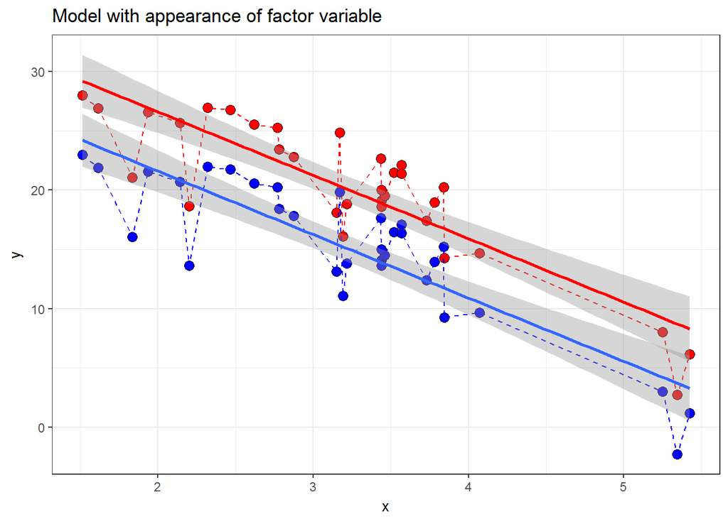

```r
model1 <- lm(mpg ~ wt + factor(am), data = data)
plot1 <- model1$fitted.values %>% as.data.frame()
names(plot1)[1] <- "m1"
plot1$m2 <- plot1$m1 - 5
plot1$x <- data$wt
plot1$m11 <- plot1$m1 - model1$residuals
plot1$m22 <- plot1$m11 - 5

plot1 %>% ggplot(aes(x,m11,)) +
  geom_point(fill = "red",shape = 21,size = 3) +
  geom_line(linetype = "dashed", col = "red") +
  geom_point(aes(x,m22), fill = "blue", shape =21, size = 3) +
  geom_line(aes(x,m22), col = "blue", linetype = "dashed") +
  geom_smooth(method = lm, col = "red") +
  geom_smooth(aes(x,m22),method = lm) +
  labs( x = "x", y = "y") +
  ggtitle("Model with appearance of factor variable") +
  theme_bw()
```

## 3.5 Mô hình không thỏa mãn khác điều kiện của OLS

- Kết quả ước lượng mô hình không còn chính xác và không có ý nghĩa kéo theo là các kiểm định của hàm cũng không chính xác như T-test, F-test, Normality test …

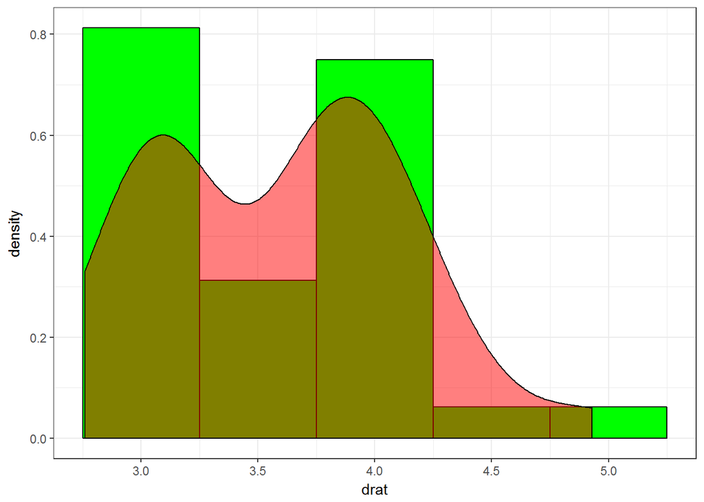

```r
data %>% ggplot(aes(x=drat)) +
  geom_histogram(aes(y=..density..),
                 binwidth = 0.5,
                 colour="black", fill="green") +
  geom_density(alpha=.5, fill="red")  +
  theme_bw()
```

```r
shapiro.test(data$drat)
```

```
##
##  Shapiro-Wilk normality test
##
## data:  data$drat
## W = 0.94588, p-value = 0.1101
```

Biến đổi biến drat như sau:

$$drat = \frac{1}{(log(drat))^2}$$

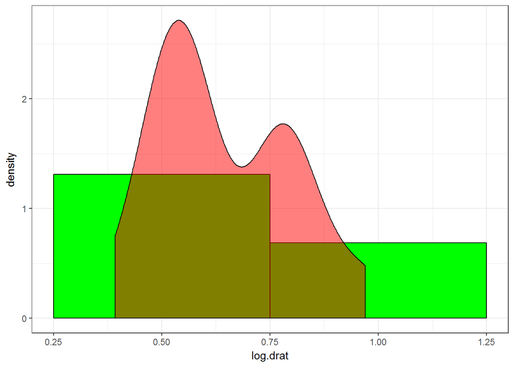

```r
data$log.drat <- 1/log(data$drat)^2
data %>% ggplot(aes(x=log.drat)) +
  geom_histogram(aes(y=..density..),
                 binwidth = 0.5,
                 colour="black", fill="green") +
  geom_density(alpha=.5, fill="red")  +
  theme_bw()
```

```r
shapiro.test(data$log.drat)
```

```
##
##  Shapiro-Wilk normality test
##
## data:  data$log.drat
## W = 0.92209, p-value = 0.0237
```